# STAT575_HW_1

Brian Zebosi

9/17/2021

### Question_1.

```r
x_1<-matrix(c(2,-1,6,-2,5,1,6,5,1,9,2,8,5,8,
            1,0,5,0,4,-2,3,3,-3,7,-4,1,0,1,
            0,2,8,-1,9,7,6,6,-3,5,-5,6,3,5),nrow=7,byrow=F)
```

## 1a.

```r
# No. rows
n<- nrow(x_1); n
```

```
## [1] 7
```

```r
# No. columns
p<- ncol(x_1); p
```

```
## [1] 6
```

## 1b.

```r
x_1[3,2]
```

```
## [1] 9
```

## 1c.

```r
colMeans(x_1)
```

```
## [1] 2.4285714 5.4285714 1.5714286 0.7142857 4.4285714 2.4285714
```

## 1d.

```r
cov(x_1)
```

```
##           [,1]      [,2]     [,3]      [,4]      [,5]      [,6]
## [1,] 10.952381  9.952381 6.880952  9.642857 10.119048 12.785714
## [2,]  9.952381  9.619048 6.047619  9.309524  9.785714 12.119048
## [3,]  6.880952  6.047619 6.285714  6.190476  5.214286  6.214286
## [4,]  9.642857  9.309524 6.190476 13.571429  7.809524 13.476190
## [5,] 10.119048  9.785714 5.214286  7.809524 16.285714 11.452381
## [6,] 12.785714 12.119048 6.214286 13.476190 11.452381 20.619048
```

## 1e.

```r
cor(x_1)
```

```
##           [,1]      [,2]      [,3]      [,4]      [,5]      [,6]
## [1,] 1.0000000 0.9696314 0.8293101 0.7909311 0.7576733 0.8508175
## [2,] 0.9696314 1.0000000 0.7777519 0.8147955 0.7818494 0.8605342
## [3,] 0.8293101 0.7777519 1.0000000 0.6702456 0.5153640 0.5458579
## [4,] 0.7909311 0.8147955 0.6702456 1.0000000 0.5253012 0.8056011
## [5,] 0.7576733 0.7818494 0.5153640 0.5253012 1.0000000 0.6249684
## [6,] 0.8508175 0.8605342 0.5458579 0.8056011 0.6249684 1.0000000
```

## 1f.

```r
t(x_1)
```

```
##      [,1] [,2] [,3] [,4] [,5] [,6] [,7]
## [1,]    2   -1    6   -2    5    1    6
## [2,]    5    1    9    2    8    5    8
## [3,]    1    0    5    0    4   -2    3
## [4,]    3   -3    7   -4    1    0    1
## [5,]    0    2    8   -1    9    7    6
## [6,]    6   -3    5   -5    6    3    5
```

## 1g.

```r
scale(x_1)
```

```
##            [,1]       [,2]       [,3]        [,4]       [,5]       [,6]
## [1,] -0.1294998 -0.1381838 -0.2279212  0.62045339 -1.0973881  0.7865162
## [2,] -1.0359980 -1.4278994 -0.6267832 -1.00823675 -0.6017935 -1.1955046
## [3,]  1.0791646  1.1515318  1.3675269  1.70624682  0.8849904  0.5662917
## [4,] -1.3381641 -1.1054705 -0.6267832 -1.27968511 -1.3451854 -1.6359537
## [5,]  0.7769985  0.8291029  0.9686649  0.07755667  1.1327877  0.7865162
## [6,] -0.4316658 -0.1381838 -1.4245072 -0.19389168  0.6371931  0.1258426
## [7,]  1.0791646  0.8291029  0.5698029  0.07755667  0.3893958  0.5662917
## attr(,"scaled:center")
## [1] 2.4285714 5.4285714 1.5714286 0.7142857 4.4285714 2.4285714
## attr(,"scaled:scale")
## [1] 3.309438 3.101459 2.507133 3.683942 4.035556 4.540820
```

## 1h.

```r
cov(scale(x_1))
```

```
##           [,1]      [,2]      [,3]      [,4]      [,5]      [,6]
## [1,] 1.0000000 0.9696314 0.8293101 0.7909311 0.7576733 0.8508175
## [2,] 0.9696314 1.0000000 0.7777519 0.8147955 0.7818494 0.8605342
## [3,] 0.8293101 0.7777519 1.0000000 0.6702456 0.5153640 0.5458579
## [4,] 0.7909311 0.8147955 0.6702456 1.0000000 0.5253012 0.8056011
## [5,] 0.7576733 0.7818494 0.5153640 0.5253012 1.0000000 0.6249684
## [6,] 0.8508175 0.8605342 0.5458579 0.8056011 0.6249684 1.0000000
```

```r
cor(scale(x_1))
```

```
##           [,1]      [,2]      [,3]      [,4]      [,5]      [,6]
## [1,] 1.0000000 0.9696314 0.8293101 0.7909311 0.7576733 0.8508175
## [2,] 0.9696314 1.0000000 0.7777519 0.8147955 0.7818494 0.8605342
## [3,] 0.8293101 0.7777519 1.0000000 0.6702456 0.5153640 0.5458579
## [4,] 0.7909311 0.8147955 0.6702456 1.0000000 0.5253012 0.8056011
## [5,] 0.7576733 0.7818494 0.5153640 0.5253012 1.0000000 0.6249684
## [6,] 0.8508175 0.8605342 0.5458579 0.8056011 0.6249684 1.0000000
```

The standardized Covariance matrix and correlation matrix are equal.

### Question_2.

```r
liver.df <- read.csv("liver_enzymes.csv")
```

## 2a.

```r
colMeans(liver.df[,2:4])
```

```
##   x1   x2   x3
## 37.6 62.5  5.8
```

## 2b.

```r
cov(liver.df[,2:4])
```

```
##           x1        x2        x3
## x1 108.71111 103.00000 16.577778
## x2 103.00000 305.61111 30.888889
## x3  16.57778  30.88889  5.511111
```

## 2c.

```r
cor(liver.df[,2:4])
```

```
##           x1        x2        x3
## x1 1.0000000 0.5650875 0.6772824
## x2 0.5650875 1.0000000 0.7526588
## x3 0.6772824 0.7526588 1.0000000
```

In the correction matrix; x2 and x3, have significant postive correlations.

## 2d

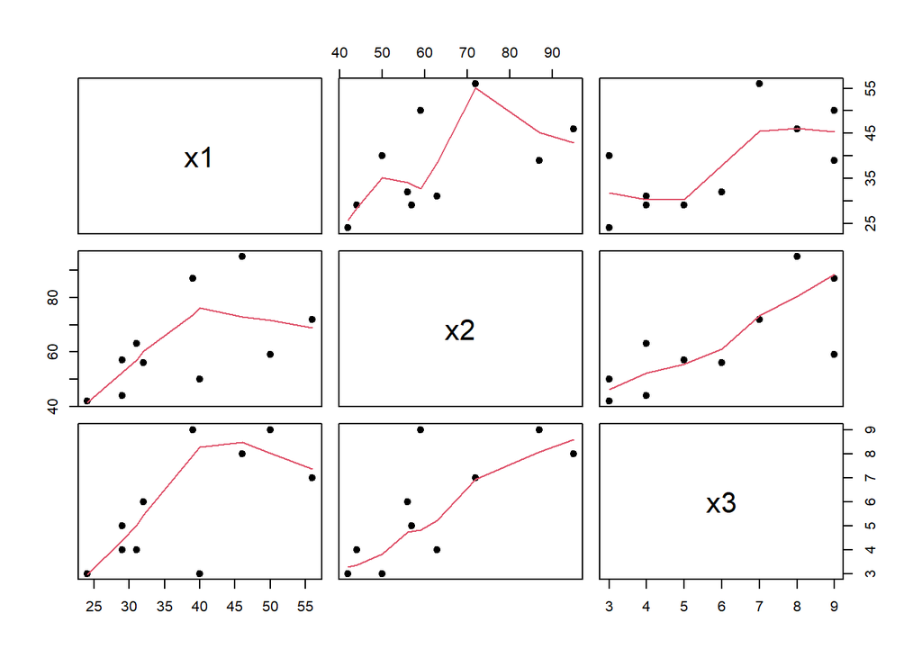

```r
pairs(liver.df[,2:4], panel = panel.smooth, pch=19)
```

Not all pairwise relationships are linear. X1 - X3, and X1 - X2 relationships look curvilinear maybe due to outliers.

## 2e.

```r
det(cov(liver.df[,2:4]))
```

```
## [1] 42403.59
```

Generalized sample variance is a measure of the total variance, which determines the normal distribution.

## 2f.

```r
sum(diag(cov(liver.df[,2:4])))
```

```
## [1] 419.8333
```

### Question_4

```r
cereal.df <- read.csv("cereal.csv")
```

## 4a.

```r
cereal.df %>% group_by(manufacturer) %>% tally() -> tallies
tallies
```

| manufacturer | n |
| --- | --- |
| A | 1 |
| G | 22 |
| K | 23 |
| N | 6 |
| P | 9 |
| Q | 8 |
| R | 8 |

## 4b.

```r
# before cleaning
dim(cereal.df)
```

```
## [1] 77 15
```

```r
## after cleaning
cereal.df %>% filter_if(is.numeric, all_vars(. >= 0)) %>% dim()
```

```
## [1] 65 15
```

There are 12 cereals with missing information.

Thus has (12/17) = 15.5% proportion.

## 4c.

```r
cereal.df %>% filter_if(is.numeric, all_vars(. >= 0)) -> cereal2.df
divide_cups <- function(x, na.rm=T)(x/cereal2.df$cups)
cereal2.df %>% select(-c(shelf,weight)) %>%
  mutate_if(is.numeric, divide_cups) -> cereal3.df
cereal3.df %>% mutate(shelf = cereal2.df$shelf) -> cereal3.df
head(cereal3.df)
```

|  | name | manufacturer | type | calories | protein | fat | sodium | fiber | carbs | sugar | potassium | vitamins | cups | shelf |
| --- | --- | --- | --- | --- | --- | --- | --- | --- | --- | --- | --- | --- | --- | --- |
| 1 | 100%_Bran | N | C | 212.1212 | 12.121212 | 3.030303 | 393.9394 | 30.303030 | 15.15152 | 18.18182 | 848.48485 | 75.75758 | 1 | 3 |
| 2 | All-Bran | K | C | 212.1212 | 12.121212 | 3.030303 | 787.8788 | 27.272727 | 21.21212 | 15.15152 | 969.69697 | 75.75758 | 1 | 3 |
| 3 | All-Bran_Extra_Fiber | K | C | 100.0000 | 8.000000 | 0.000000 | 280.0000 | 28.000000 | 16.00000 | 0.00000 | 660.00000 | 50.00000 | 1 | 3 |
| 4 | Apple_Cin_Cheerios | G | C | 146.6667 | 2.666667 | 2.666667 | 240.0000 | 2.000000 | 14.00000 | 13.33333 | 93.33333 | 33.33333 | 1 | 1 |
| 5 | Apple_Jacks | K | C | 110.0000 | 2.000000 | 0.000000 | 125.0000 | 1.000000 | 11.00000 | 14.00000 | 30.00000 | 25.00000 | 1 | 2 |
| 6 | Basic_4 | G | C | 173.3333 | 4.000000 | 2.666667 | 280.0000 | 2.666667 | 24.00000 | 10.66667 | 133.33333 | 33.33333 | 1 | 3 |

## 4d.

i).

Highest numbers of calories per cup

```r
cereal3.df$name[cereal3.df$calories==max(cereal3.df$calories)]
```

```
## [1] "Grape-Nuts"
```

Lowest numbers of calories per cup

```r
cereal3.df$name[cereal3.df$calories==min(cereal3.df$calories)]
```

```
## [1] "Puffed_Rice"
```

ii).

Highest numbers of vitamins per cup

```r
cereal3.df$name[cereal3.df$vitamins==max(cereal3.df$vitamins)]
```

```
## [1] "Just_Right_Fruit_Nut"
```

Lowest numbers of vitamins per cup

```r
cereal3.df$name[cereal3.df$vitamins==min(cereal3.df$vitamins)]
```

```
## [1] "Puffed_Rice"          "Shredded_Wheat_Bran"  "Shredded_Wheat_spoon"
```

iii).

[output not shown]

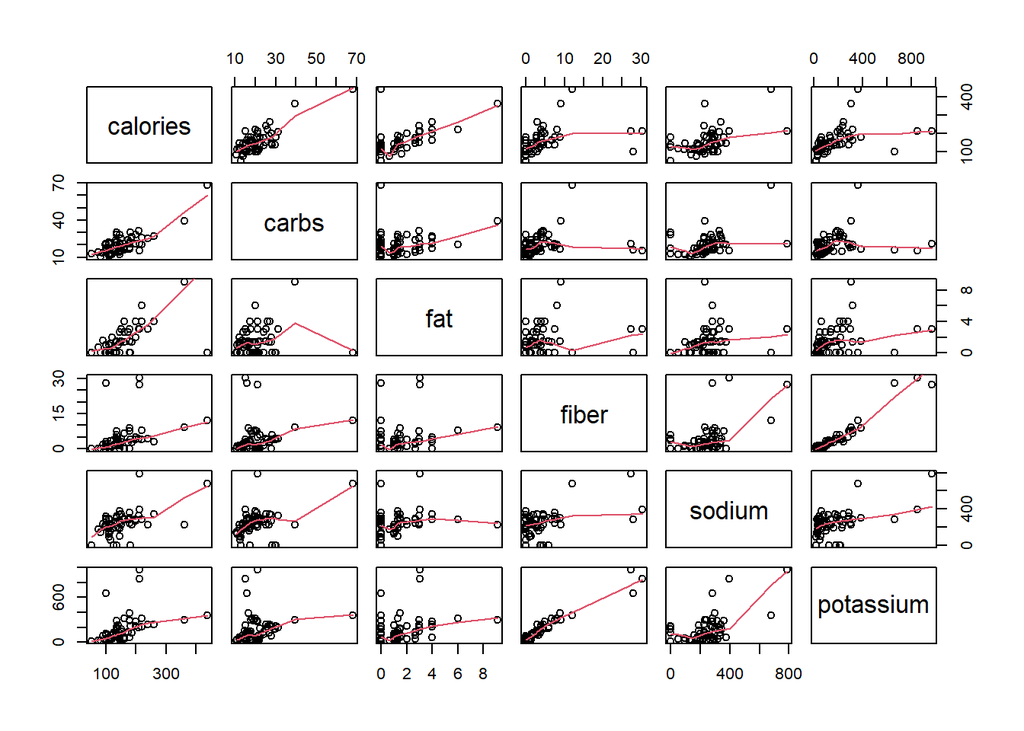

```r
variable <- c("calories", "carbs", "fat","fiber", "sodium","potassium")
cereal3.df %>% select(variable) %>% pairs(panel = panel.smooth)
```

The cereals that are outliers with respect to calories only are

```r
cereal3.df$name[cereal3.df$calories >300]
```

```
## [1] "Grape-Nuts"         "Great_Grains_Pecan"
```

The cereals that is outlier with respect to carbs only is:

```r
cereal3.df$name[cereal3.df$carbs >50]
```

```
## [1] "Grape-Nuts"
```

The cereals that is outliers with respect to both calories and carbs is:

```r
cereal3.df$name[cereal3.df$carbs >50 & cereal3.df$calories >300]
```

```
## [1] "Grape-Nuts"
```

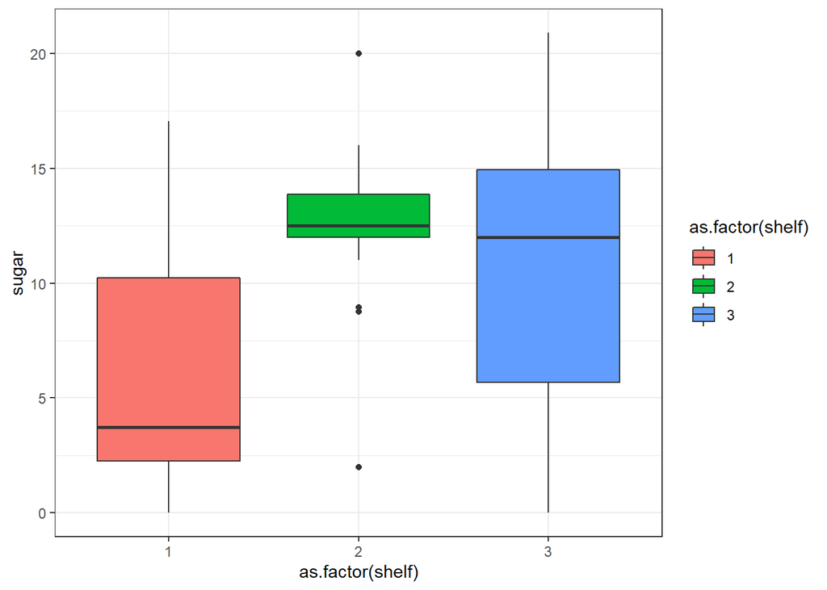

```r
cereal3.df$shelf <- as.factor(cereal3.df$shelf)
ggplot(cereal3.df, aes(y = sugar, x = as.factor(shelf), fill = as.factor(shelf))) + geom_boxplot() + theme_bw()
```

Distribution of sugar on shelf 3 had greater variation.

Distribution at shelf 1 was right skewed with low median i.e. lowest sugar per cur.

Distribution of sugar on shelf 2 displayed small variation with outliers and also highest sugar per cup.

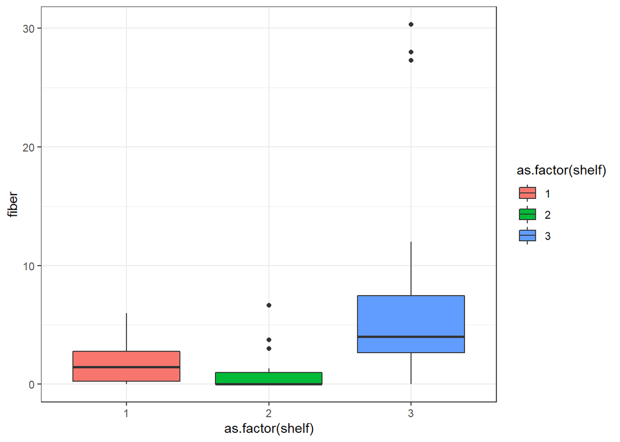

```r
ggplot(cereal3.df, aes(y = fiber, x = as.factor(shelf), fill = as.factor(shelf))) + geom_boxplot() + theme_bw()
```

Distribution of fiber per cup on shelf 3 is more variable and has the highest fibre per cup.

Distribution at shelf 1 was right skewed

Distribution of sugar on shelf 2 displayed small variation with outliers and also lowest fibre per cup.

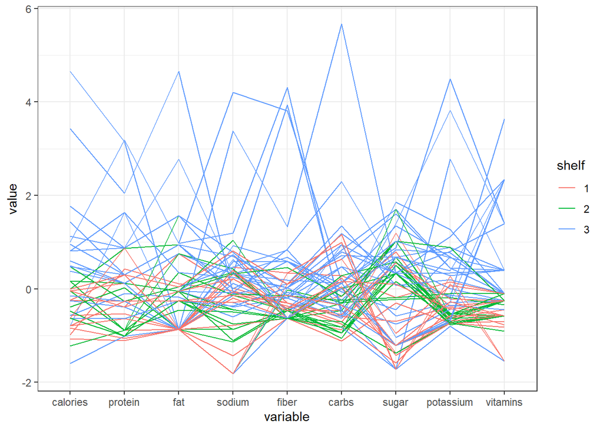

```r
ggparcoord(cereal3.df, columns = 4:12, groupColumn ="shelf") + theme_bw()
```

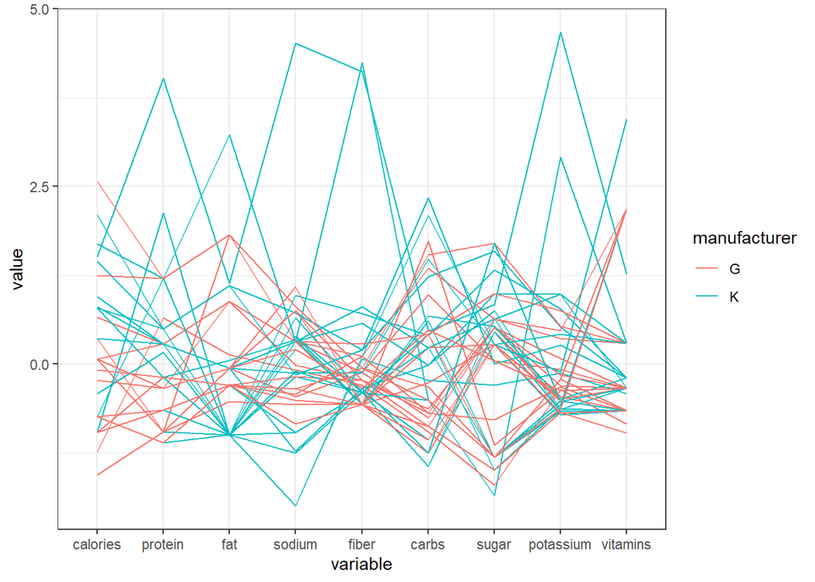

```r
cereal3_KG <- filter(cereal3.df, manufacturer =="K" | manufacturer =="G")

ggparcoord(cereal3_KG, columns = 4:12, groupColumn ="manufacturer") + theme_bw()
```

Generally Kellogg Mills cereals have higher nutrition than General Mills cereals.

General mills have lower carbs content and higher fat content compared to Kellogg cereals.

Kellogg mills have more fiber, protein, potassium.